# 02_are_points_a_function

## 02_are_points_a_function

#### Question

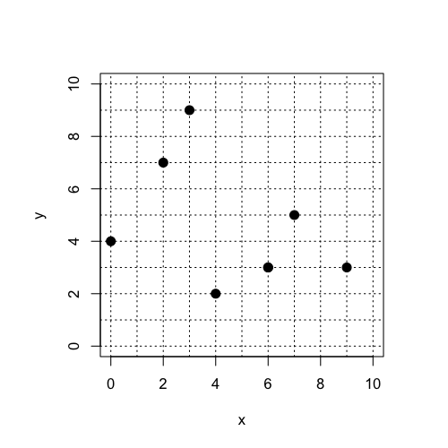

1. Are these points consistent with $y$ being a function of $x$?

   Are these points consistent with $x$ being a function of $y$?

   Are these points consistent with a one-to-one function?

#### Question

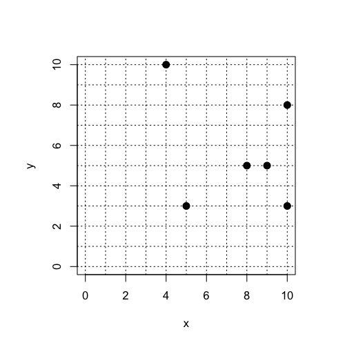

2. Are these points consistent with $y$ being a function of $x$?

   Are these points consistent with $x$ being a function of $y$?

   Are these points consistent with a one-to-one function?

#### Question

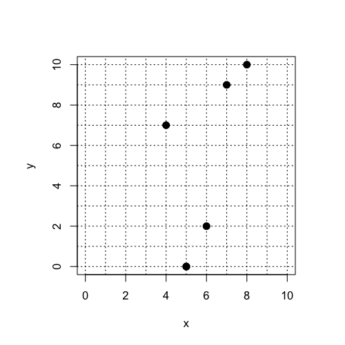

3. Are these points consistent with $y$ being a function of $x$?

   Are these points consistent with $x$ being a function of $y$?

   Are these points consistent with a one-to-one function?

#### Question

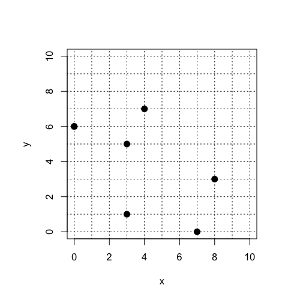

4. Are these points consistent with $y$ being a function of $x$?

   Are these points consistent with $x$ being a function of $y$?

   Are these points consistent with a one-to-one function?

#### Question

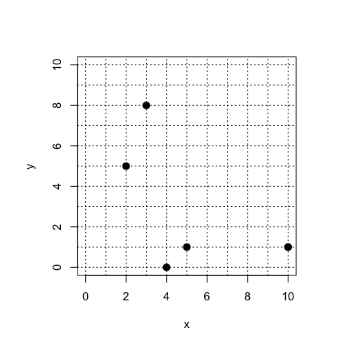

5. Are these points consistent with $y$ being a function of $x$?

   Are these points consistent with $x$ being a function of $y$?

   Are these points consistent with a one-to-one function?

#### Question

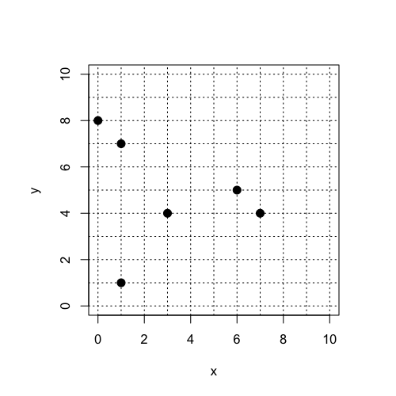

6. Are these points consistent with $y$ being a function of $x$?

   Are these points consistent with $x$ being a function of $y$?

   Are these points consistent with a one-to-one function?

#### Question

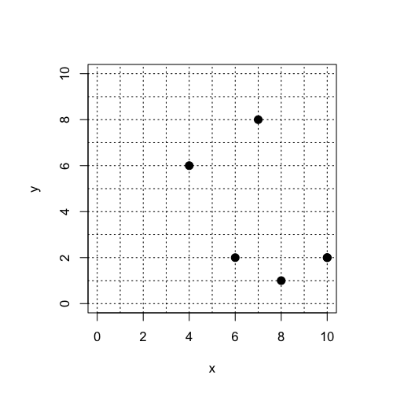

7. Are these points consistent with $y$ being a function of $x$?

   Are these points consistent with $x$ being a function of $y$?

   Are these points consistent with a one-to-one function?

#### Question

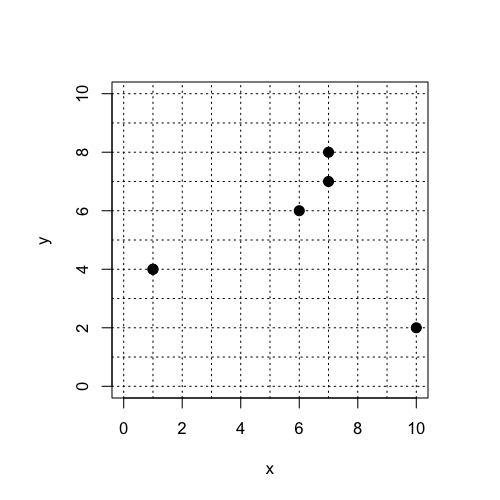

8. Are these points consistent with $y$ being a function of $x$?

   Are these points consistent with $x$ being a function of $y$?

   Are these points consistent with a one-to-one function?